# Palmer Penguins Analysis

Caroline Carrozzini

1/10/2023

```r
knitr::opts_chunk$set(echo = TRUE)
#Load the tidyverse
library(tidyverse)
library(kableExtra)
#Read the penguins_samp1 data file from github
penguins <- read_csv("https://raw.githubusercontent.com/mcduryea/Intro-to-Bioinformatics/main/data/penguins_samp1.csv")
#See the first six rows of the data we've read in to our notebook
penguins %>%
  head() %>%
  kable () %>%
  kable_styling(c("striped", "hover"))
```

| species | island | bill_length_mm | bill_depth_mm | flipper_length_mm | body_mass_g | sex | year |
| --- | --- | --- | --- | --- | --- | --- | --- |
| Gentoo | Biscoe | 59.6 | 17.0 | 230 | 6050 | male | 2007 |
| Gentoo | Biscoe | 48.6 | 16.0 | 230 | 5800 | male | 2008 |
| Gentoo | Biscoe | 52.1 | 17.0 | 230 | 5550 | male | 2009 |
| Gentoo | Biscoe | 51.5 | 16.3 | 230 | 5500 | male | 2009 |
| Gentoo | Biscoe | 55.1 | 16.0 | 230 | 5850 | male | 2009 |
| Gentoo | Biscoe | 49.8 | 15.9 | 229 | 5950 | male | 2009 |

# About our Data

The data we are working with is a dataset on Penguins, which includes 8 features measured on 44 penguins. The features included are physiological features (like bill length, bill depth, flipper length, body mass, etc) as well as other features like the year that the penguin was observed, the island the penguin was observed on, the sex of the penguin, and the species of the penguin.

# Interesting Questions to Ask

- What is the average flipper length? What about for each species?
- Are there more male or female penguins? What about per island or species?
- What is the average body mass? What about by island? By species? By sex?
- What is the ratio of bill length to bill depth for a penguin? What is the overall average of this metric? Does it change by species, sex, or island?
- Does average body mass change by year?

# Data Manipulation Tools and Strategies

```r
penguins %>%
  select(species, body_mass_g)
```

```
## # A tibble: 44 × 2
##    species body_mass_g
##    <chr>         <dbl>
##  1 Gentoo         6050
##  2 Gentoo         5800
##  3 Gentoo         5550
##  4 Gentoo         5500
##  5 Gentoo         5850
##  6 Gentoo         5950
##  7 Gentoo         5700
##  8 Gentoo         5350
##  9 Gentoo         5550
## 10 Gentoo         6300
## # … with 34 more rows
```

If we want to `filter()` and only show certain rows, we can do that too.

```r
# we can filter by sex (categorical variables)
penguins %>%
  filter(species == "Chinstrap")
```

```
## # A tibble: 2 × 8
##   species   island bill_length_mm bill_depth_mm flipper_le…¹ body_…² sex    year
##   <chr>     <chr>           <dbl>         <dbl>        <dbl>   <dbl> <chr> <dbl>
## 1 Chinstrap Dream            55.8          19.8          207    4000 male   2009
## 2 Chinstrap Dream            46.6          17.8          193    3800 fema…  2007
## # … with abbreviated variable names ¹flipper_length_mm, ²body_mass_g
```

```r
# we can also filter by numerical variables
penguins %>%
  filter(body_mass_g >=6000)
```

```
## # A tibble: 2 × 8
##   species island bill_length_mm bill_depth_mm flipper_leng…¹ body_…² sex    year
##   <chr>   <chr>           <dbl>         <dbl>          <dbl>   <dbl> <chr> <dbl>
## 1 Gentoo  Biscoe           59.6          17              230    6050 male   2007
## 2 Gentoo  Biscoe           49.2          15.2            221    6300 male   2007
## # … with abbreviated variable names ¹flipper_length_mm, ²body_mass_g
```

```r
# we can also do both
penguins %>%
  filter((body_mass_g >= 6000) | (island == "Torgersen"))
```

```
## # A tibble: 7 × 8
##   species island    bill_length_mm bill_depth_mm flipper_l…¹ body_…² sex    year
##   <chr>   <chr>              <dbl>         <dbl>       <dbl>   <dbl> <chr> <dbl>
## 1 Gentoo  Biscoe              59.6          17           230    6050 male   2007
## 2 Gentoo  Biscoe              49.2          15.2         221    6300 male   2007
## 3 Adelie  Torgersen           40.6          19           199    4000 male   2009
## 4 Adelie  Torgersen           38.8          17.6         191    3275 fema…  2009
## 5 Adelie  Torgersen           41.1          18.6         189    3325 male   2009
## 6 Adelie  Torgersen           38.6          17           188    2900 fema…  2009
## 7 Adelie  Torgersen           36.2          17.2         187    3150 fema…  2009
## # … with abbreviated variable names ¹flipper_length_mm, ²body_mass_g
```

# Answering Our Questions

Most of our questions involve summarizing data, and perhaps summarizing over groups. We can summarize data using the `summarize()` function, and group data using `group_by()`.

Let’s find the average flipper length.

```r
penguins %>%
  summarize(avg_flipper_length = mean(flipper_length_mm))
```

```
## # A tibble: 1 × 1
##   avg_flipper_length
##                <dbl>
## 1               212.
```

```r
# Single Species Average
penguins %>%
  filter(species == "Gentoo") %>%
  summarize (avg_flipper_length = mean(flipper_length_mm))
```

```
## # A tibble: 1 × 1
##   avg_flipper_length
##                <dbl>
## 1               218.
```

```r
# Grouped Average
penguins %>%
  group_by(species)
```

```
## # A tibble: 44 × 8
## # Groups:   species [3]
##    species island bill_length_mm bill_depth_mm flipper_len…¹ body_…² sex    year
##    <chr>   <chr>           <dbl>         <dbl>         <dbl>   <dbl> <chr> <dbl>
##  1 Gentoo  Biscoe           59.6          17             230    6050 male   2007
##  2 Gentoo  Biscoe           48.6          16             230    5800 male   2008
##  3 Gentoo  Biscoe           52.1          17             230    5550 male   2009
##  4 Gentoo  Biscoe           51.5          16.3           230    5500 male   2009
##  5 Gentoo  Biscoe           55.1          16             230    5850 male   2009
##  6 Gentoo  Biscoe           49.8          15.9           229    5950 male   2009
##  7 Gentoo  Biscoe           49.6          16             225    5700 male   2008
##  8 Gentoo  Biscoe           50            15.9           224    5350 male   2009
##  9 Gentoo  Biscoe           50.5          15.9           222    5550 male   2008
## 10 Gentoo  Biscoe           49.2          15.2           221    6300 male   2007
## # … with 34 more rows, and abbreviated variable names ¹flipper_length_mm,
## #   ²body_mass_g
```

How many of each species do we have?

```r
penguins %>%
  count(species)
```

```
## # A tibble: 3 × 2
##   species       n
##   <chr>     <int>
## 1 Adelie        9
## 2 Chinstrap     2
## 3 Gentoo       33
```

```r
penguins %>%
  group_by(species) %>%
  count(sex)
```

```
## # A tibble: 6 × 3
## # Groups:   species [3]
##   species   sex        n
##   <chr>     <chr>  <int>
## 1 Adelie    female     6
## 2 Adelie    male       3
## 3 Chinstrap female     1
## 4 Chinstrap male       1
## 5 Gentoo    female    13
## 6 Gentoo    male      20
```

We can use `mutate()` to aedd new columns to our data set.

```r
#To make a permanent change, we need to store the results of our manipulations
penguins_with_ratio <- penguins  %>%
  mutate(bill_ltd_ratio = bill_length_mm / bill_depth_mm)

#Average Ratio
penguins %>%
  mutate(bill_ltd_ratio = bill_length_mm / bill_depth_mm) %>%
  summarize(mean_bill_ltd_ratio = mean(bill_ltd_ratio), median_bill_ltd_ratio = median(bill_ltd_ratio))
```

```
## # A tibble: 1 × 2
##   mean_bill_ltd_ratio median_bill_ltd_ratio
##                 <dbl>                 <dbl>
## 1                2.95                  3.06
```

```r
#Average Ratio by Group
penguins %>%
  group_by(species) %>%
   mutate(bill_ltd_ratio = bill_length_mm / bill_depth_mm) %>%
  summarize(mean_bill_ltd_ratio = mean(bill_ltd_ratio), median_bill_ltd_ratio = median(bill_ltd_ratio))
```

```
## # A tibble: 3 × 3
##   species   mean_bill_ltd_ratio median_bill_ltd_ratio
##   <chr>                   <dbl>                 <dbl>
## 1 Adelie                   2.20                  2.20
## 2 Chinstrap                2.72                  2.72
## 3 Gentoo                   3.17                  3.13
```

Average body mass by year

```r
penguins %>%
  group_by(year) %>%
  summarize(mean_body_mass = mean(body_mass_g))
```

```
## # A tibble: 3 × 2
##    year mean_body_mass
##   <dbl>          <dbl>
## 1  2007          5079.
## 2  2008          4929.
## 3  2009          4518.
```

# Data Visualization Rules

- One numerical variable - histogram/barplot
- One categorical - barplot
- Two numerical variables - scatterplot
- Two categorical variables - barplots with fill
- One numerical and one categorical variable - side-by-side boxplots “faceting”

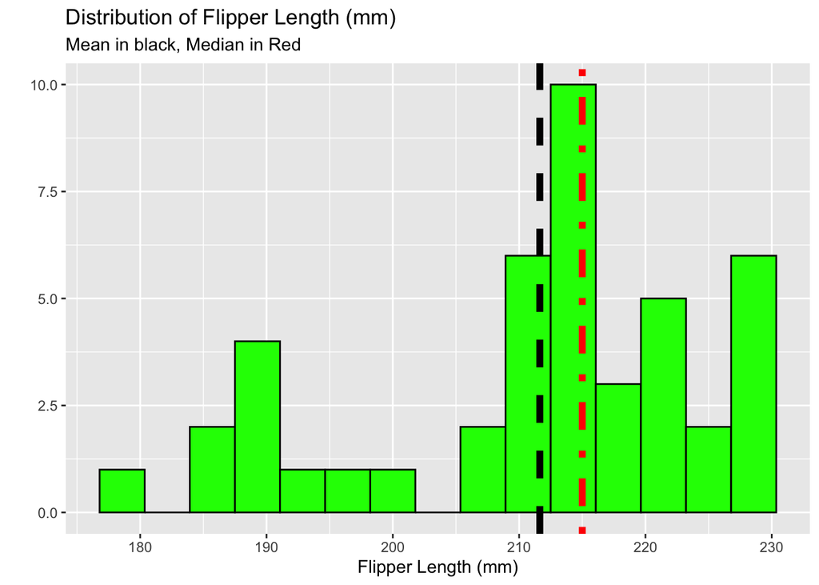

```r
penguins %>%
  ggplot() +
  geom_histogram(aes(x = flipper_length_mm),
                 bins = 15,
                 fill = " green",
                 color = "black") +
  labs(title = "Distribution of Flipper Length (mm)", subtitle = "Mean in black, Median in Red", y = "", x = "Flipper Length (mm)") + geom_vline(aes(xintercept = mean(flipper_length_mm)), lwd = 2, lty = "dashed") + geom_vline(aes(xintercept = median(flipper_length_mm)), lwd = 2, lty = "dotdash", color = "red")
```

# We will now look at the distribution of species.

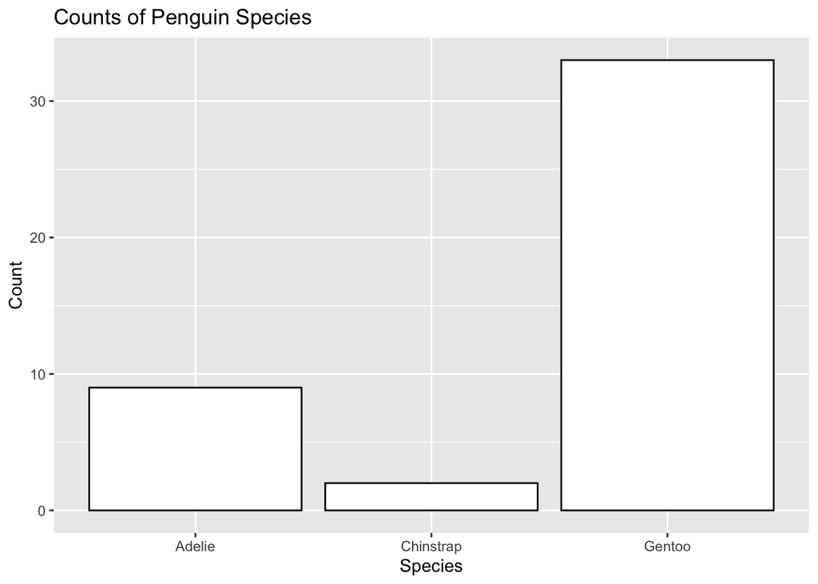

```r
penguins %>%
  ggplot() +
  geom_bar(mapping = aes(x = species), color = "black", fill = "white") + labs(title = "Counts of Penguin Species", x = "Species", y = "Count")
```

# Let’s make a scatter plot to see if bill length is correlated with bill depth.

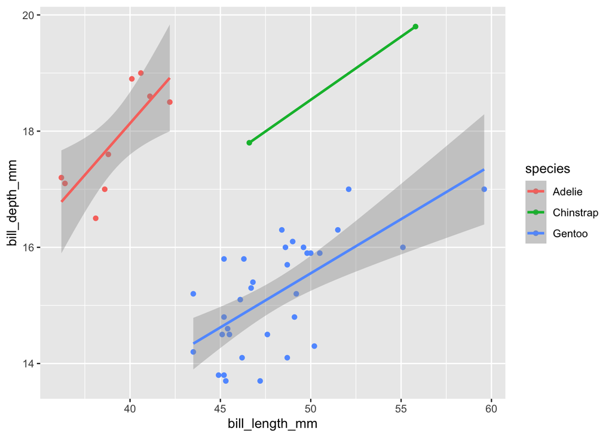

```r
penguins %>%
  ggplot() +
  geom_point(aes(x = bill_length_mm, y = bill_depth_mm, color = species)) +
  geom_smooth(aes(x = bill_length_mm, y = bill_depth_mm, color = species), method = "lm")
```

# 1/24/23

```r
library(tidyverse)
library(kableExtra)
penguins %>%
  summarize(avg_bill_length = mean(bill_length_mm))
```

```
## # A tibble: 1 × 1
##   avg_bill_length
##             <dbl>
## 1            46.4
```

```r
t.test(penguins$bill_length_mm, alternative = "greater", mu = 45, conf.level = 0.95)
```

```
##
##  One Sample t-test
##
## data:  penguins$bill_length_mm
## t = 1.8438, df = 43, p-value = 0.03606
## alternative hypothesis: true mean is greater than 45
## 95 percent confidence interval:
##  45.12094      Inf
## sample estimates:
## mean of x
##  46.37045
```

- The work above is not ethical due to the fact that R created the test and both tried to solve it. # Reviewing Statistics
- We assumed the central limit theorem
  - The sampling distribution tends towards a normal distribution as sample sizes get larger # Simulation-based Methods
- Assumption: our data is randomly sampled and is representative of our population
  - Bootstrapping: Treating our sample as if it were the population

# Homework 1/26 Summarizing Data

```r
penguins%>%
    count(island)
```

```
## # A tibble: 3 × 2
##   island        n
##   <chr>     <int>
## 1 Biscoe       36
## 2 Dream         3
## 3 Torgersen     5
```

- This output shows us the number of penguins on a specified island.

```r
penguins%>%
  count(species)
```

```
## # A tibble: 3 × 2
##   species       n
##   <chr>     <int>
## 1 Adelie        9
## 2 Chinstrap     2
## 3 Gentoo       33
```

- This code cell gives us the number of penguins per specified species.

```r
penguins%>%
  count(island, species) %>%
  pivot_wider(names_from = species, values_from = n, values_fill = 0) %>%
  kable() %>%
  kable_styling(bootstrap_options = c("hover", "striped"))
```

| island | Adelie | Gentoo | Chinstrap |
| --- | --- | --- | --- |
| Biscoe | 3 | 33 | 0 |
| Dream | 1 | 0 | 2 |
| Torgersen | 5 | 0 | 0 |

- This output separates penguins per species per island rather than the previous two which only focus on one specific variable.

# Getting the Average

```r
penguins%>%
  summarize(mean_bill_length_mm = mean(bill_length_mm, na.rm = TRUE))
```

```
## # A tibble: 1 × 1
##   mean_bill_length_mm
##                 <dbl>
## 1                46.4
```

```r
penguins %>%
  summarize(
    min_bill_length = min(bill_length_mm, na.rm = TRUE),
    first_quartile_bill_length = quantile(bill_length_mm, 0.25, na.rm = TRUE),
    median_bill_length = median(bill_length_mm, na.rm = TRUE),
    mean_bill_length_mm = mean(bill_length_mm, na.rm = TRUE),
    third_quartile_bill_length = quantile(bill_length_mm, 0.75, na.rm = TRUE),
    standard_deviation_bill_length = sd(bill_length_mm, na.rm = TRUE)
    ) %>%
  pivot_longer(cols = everything())
```

```
## # A tibble: 6 × 2
##   name                           value
##   <chr>                          <dbl>
## 1 min_bill_length                36.2
## 2 first_quartile_bill_length     44.6
## 3 median_bill_length             46.4
## 4 mean_bill_length_mm            46.4
## 5 third_quartile_bill_length     49.1
## 6 standard_deviation_bill_length  4.93
```

```r
penguins %>%
  summarize(
    min_bill_length = min(bill_length_mm, na.rm = TRUE),
    first_quartile_bill_length = quantile(bill_length_mm, 0.25, na.rm = TRUE),
    median_bill_length = median(bill_length_mm, na.rm = TRUE),
    mean_bill_length_mm = mean(bill_length_mm, na.rm = TRUE),
    third_quartile_bill_length = quantile(bill_length_mm, 0.75, na.rm = TRUE),
    standard_deviation_bill_length = sd(bill_length_mm, na.rm = TRUE)
    ) %>%
  kable() %>%
  kable_styling(bootstrap_options = c("hover", "striped"))
```

| min_bill_length | first_quartile_bill_length | median_bill_length | mean_bill_length_mm | third_quartile_bill_length | standard_deviation_bill_length |
| --- | --- | --- | --- | --- | --- |
| 36.2 | 44.55 | 46.45 | 46.37045 | 49.125 | 4.930379 |

- Don’t change that last line because it’s ugly now.

# Selecting Specific Columns and Rows

```r
penguins %>%
  select(species, island, sex, year)
```

```
## # A tibble: 44 × 4
##    species island sex    year
##    <chr>   <chr>  <chr> <dbl>
##  1 Gentoo  Biscoe male   2007
##  2 Gentoo  Biscoe male   2008
##  3 Gentoo  Biscoe male   2009
##  4 Gentoo  Biscoe male   2009
##  5 Gentoo  Biscoe male   2009
##  6 Gentoo  Biscoe male   2009
##  7 Gentoo  Biscoe male   2008
##  8 Gentoo  Biscoe male   2009
##  9 Gentoo  Biscoe male   2008
## 10 Gentoo  Biscoe male   2007
## # … with 34 more rows
```

```r
penguins %>%
  select(species, island, sex, year) %>%
  filter(species == "Chinstrap")
```

```
## # A tibble: 2 × 4
##   species   island sex     year
##   <chr>     <chr>  <chr>  <dbl>
## 1 Chinstrap Dream  male    2009
## 2 Chinstrap Dream  female  2007
```

```r
chinstraps <- penguins %>%
  select(species, island, sex, year) %>%
  filter(species == "Chinstrap") %>%
  select(-species)

chinstraps %>%
  head()
```

```
## # A tibble: 2 × 3
##   island sex     year
##   <chr>  <chr>  <dbl>
## 1 Dream  male    2009
## 2 Dream  female  2007
```

# Grouping and Summarizing

```r
penguins %>%
  group_by(species) %>%
  summarise(
    mean_bill_depth_mm = mean(bill_depth_mm, na.rm = TRUE),
    sd_bill_depth_mm = sd(bill_depth_mm, na.rm = TRUE)
  )
```

```
## # A tibble: 3 × 3
##   species   mean_bill_depth_mm sd_bill_depth_mm
##   <chr>                  <dbl>            <dbl>
## 1 Adelie                  17.8            0.935
## 2 Chinstrap               18.8            1.41
## 3 Gentoo                  15.2            0.951
```

- What I’ve noticed is that this code populates a chart categorizing species by the mean and standard deviation based off bill depths.

# Data Visualization with `ggplot()`

One Categorical Variable: We can visualize a categorical variable with a barplot.

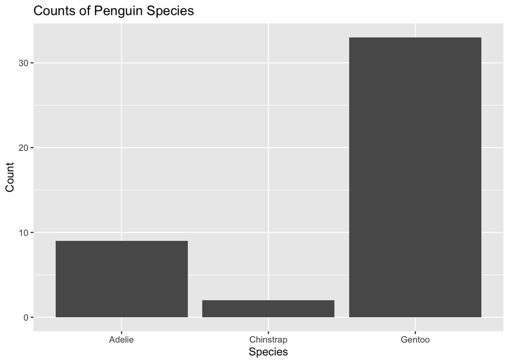

```r
penguins %>%
  ggplot() +
  geom_bar(mapping = aes(x = species)) +
  labs(title = "Counts of Penguin Species",
       x = "Species", y = "Count")
```

- This plot is a ggplot which uses + signs. These + signs are used to specify which variables we want to use, the types of titles we use, and some visual components. I’m guessing that we use + signs so that the system can we realize what type of information we are adding (meaning that we’re not adding anything new and just visually modifying what is exported).

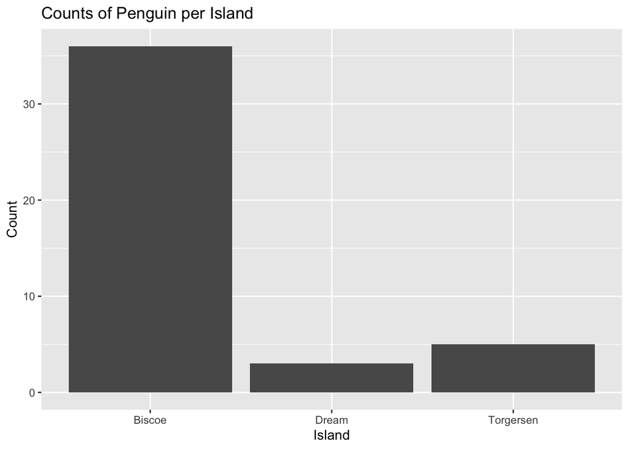

```r
penguins %>%
  ggplot() +
  geom_bar(mapping = aes(x = island)) +
  labs(title = "Counts of Penguin per Island",
       x = "Island", y = "Count")
```

- This ggplot is doing the same thing as the previous one but instead looks at the count of penguins per island rather than species.

One Numerical Variable: uses histogram, density, or boxplot

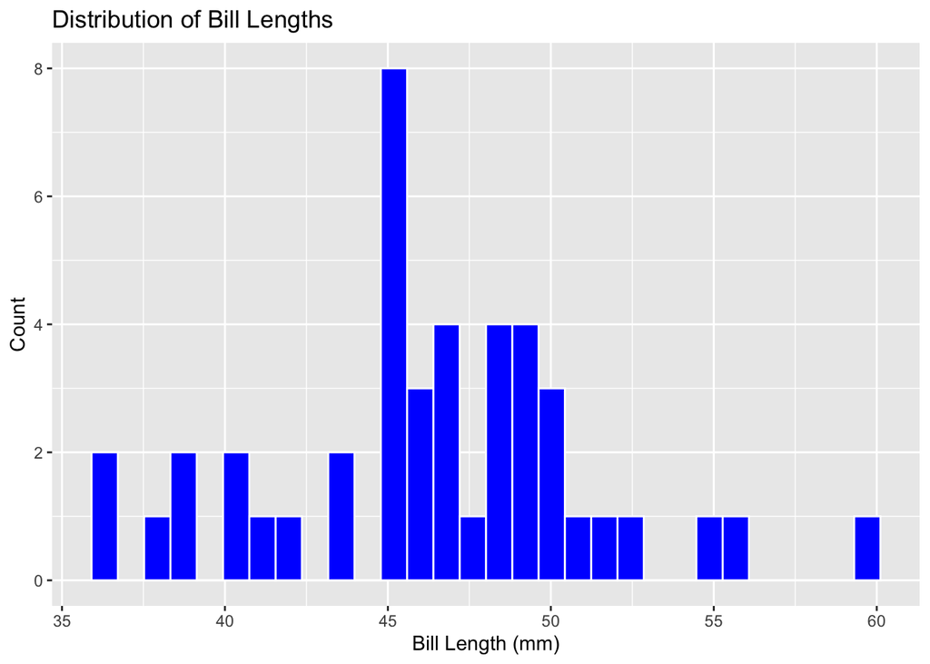

```r
penguins %>%
  ggplot() +
  geom_histogram(mapping = aes(x = bill_length_mm),
                 color = "white",
                 fill = "blue") +
  labs(title ="Distribution of Bill Lengths",
       x = "Bill Length (mm)", y = "Count")
```

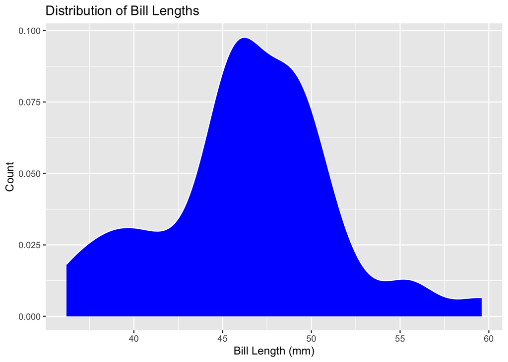

```r
penguins %>%
  ggplot() +
  geom_density(mapping = aes(x = bill_length_mm),
                 color = "white",
                 fill = "blue") +
  labs(title ="Distribution of Bill Lengths",
       x = "Bill Length (mm)", y = "Count")
```

These plots, both histogram and density, are showing the distribution of penguins with a certain bill length. The histogram, I think, does a much better job at showing the distributions whereas you wouldn’t be able to pinpoint exactly how many penguins have a specific bill length.

Two Numerical Variables: relationship between two numerical variables with scatterplot

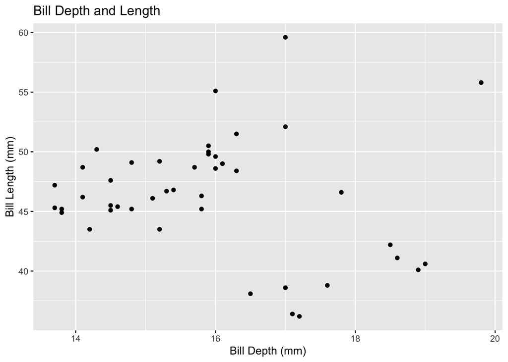

```r
penguins %>%
  ggplot() +
  geom_point(mapping = aes(x = bill_depth_mm, y = bill_length_mm)) +
  labs(title = "Bill Depth and Length",
       x = "Bill Depth (mm)",
       y = "Bill Length (mm)")
```

- I think what I found most interesting is that the data doesn’t stay consistent in terms of the trends. Some of our data points later on to the right in our graph, specifically the one that lies all the way at the end, looks like it would be an outlier.

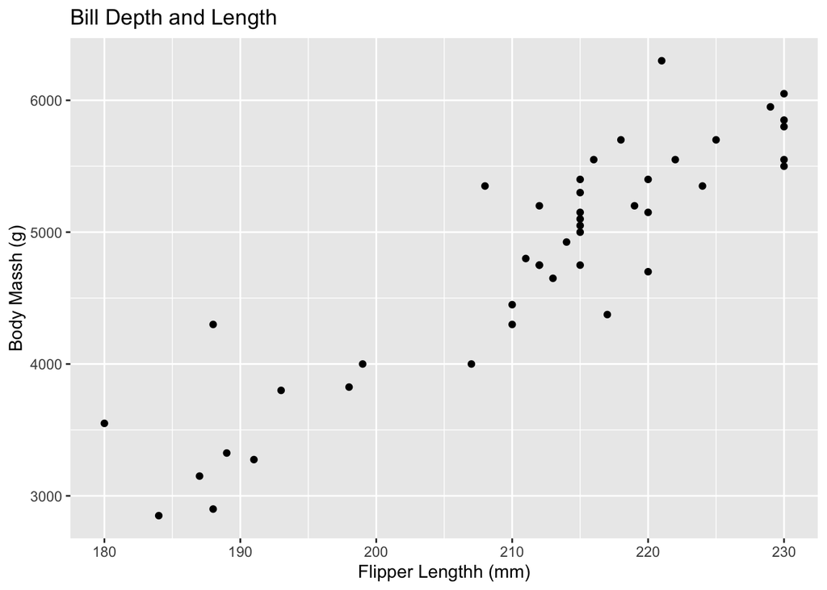

```r
penguins %>%
  ggplot() +
  geom_point(mapping = aes(x = flipper_length_mm, y = body_mass_g)) +
  labs(title = "Bill Depth and Length",
       x = "Flipper Lengthh (mm)",
       y = "Body Massh (g)")
```

# Two Categorical Variables: associations between pairs of categorical variables using barplots and fill

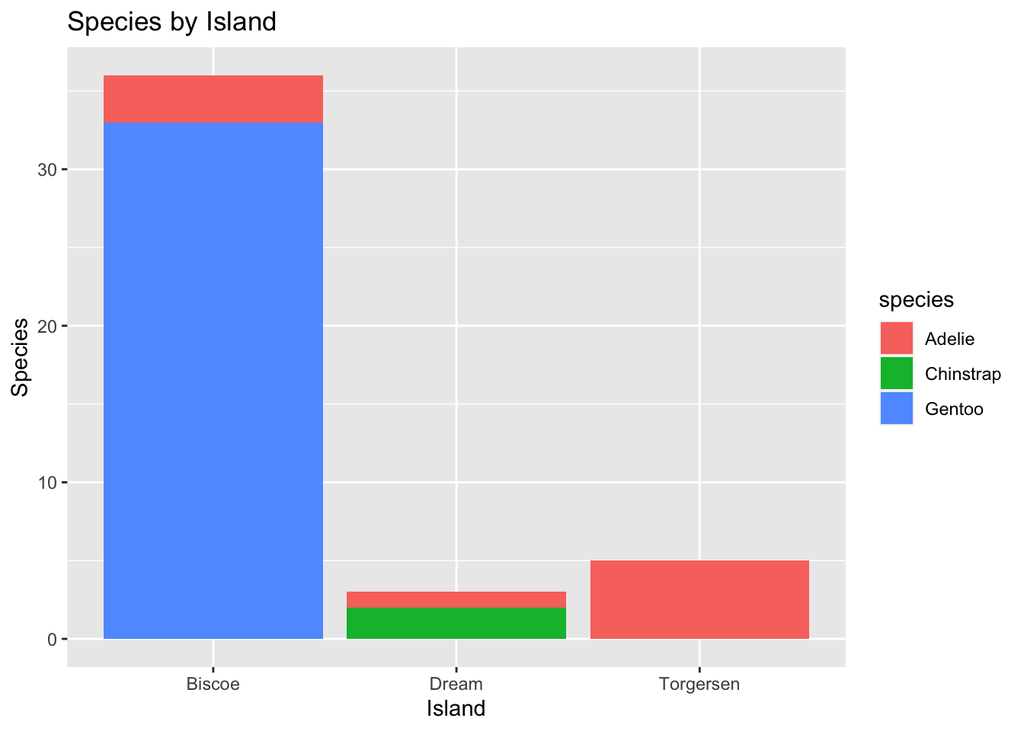

```r
penguins %>%
  ggplot() +
  geom_bar(mapping = aes(x = island, fill = species)) +
  labs(title = "Species by Island",
       x = "Island",
       y = "Species")
```

- This plot uses more visually appealing data to show the distribution of species of animal per island using different colors. I like this plot because it very easy to put into perspective tons of different factors such as the distribution of species per island compared to the other islands or which species is more populated in which areas. # One Numerical and One Categorical Variable: effective visualizations

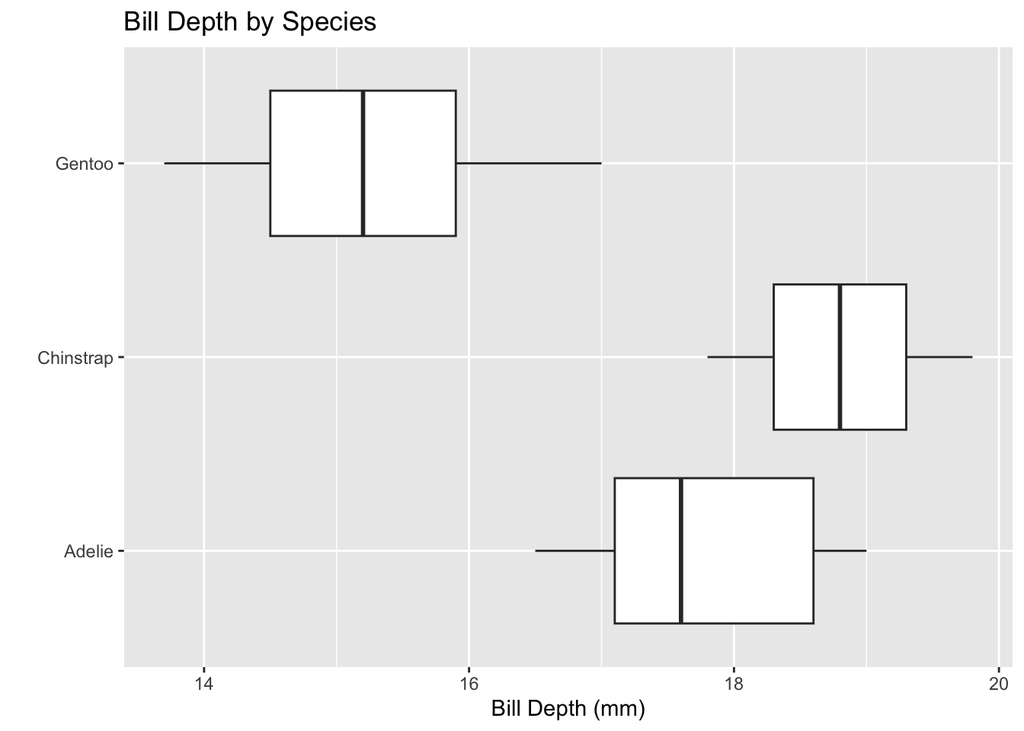

```r
penguins %>%
  ggplot() +
  geom_boxplot(mapping = aes(x = bill_depth_mm, y = species)) +
  labs(title = "Bill Depth by Species",
       x = "Bill Depth (mm)",
       y = "")
```

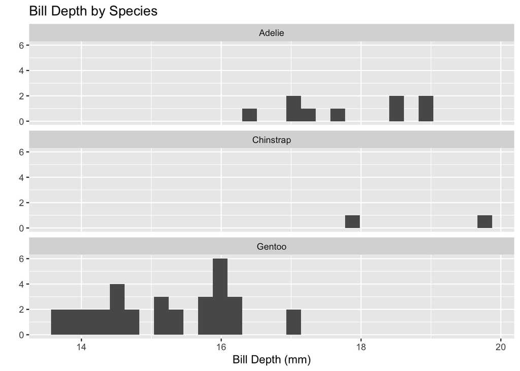

```r
penguins %>%
  ggplot() +
  geom_histogram(mapping = aes(x = bill_depth_mm)) +
  facet_wrap(~species, ncol = 1) +
  labs(title = "Bill Depth by Species",
       x = "Bill Depth (mm)",
       y = "")
```

- In these plots, we are visualizing bill depth by species in two different ways. The first one is a boxplot and the second one is a histogram. If you understand boxplots, then the first one will make sense. If you don’t, the second one helps you to visualize the information much more easily.

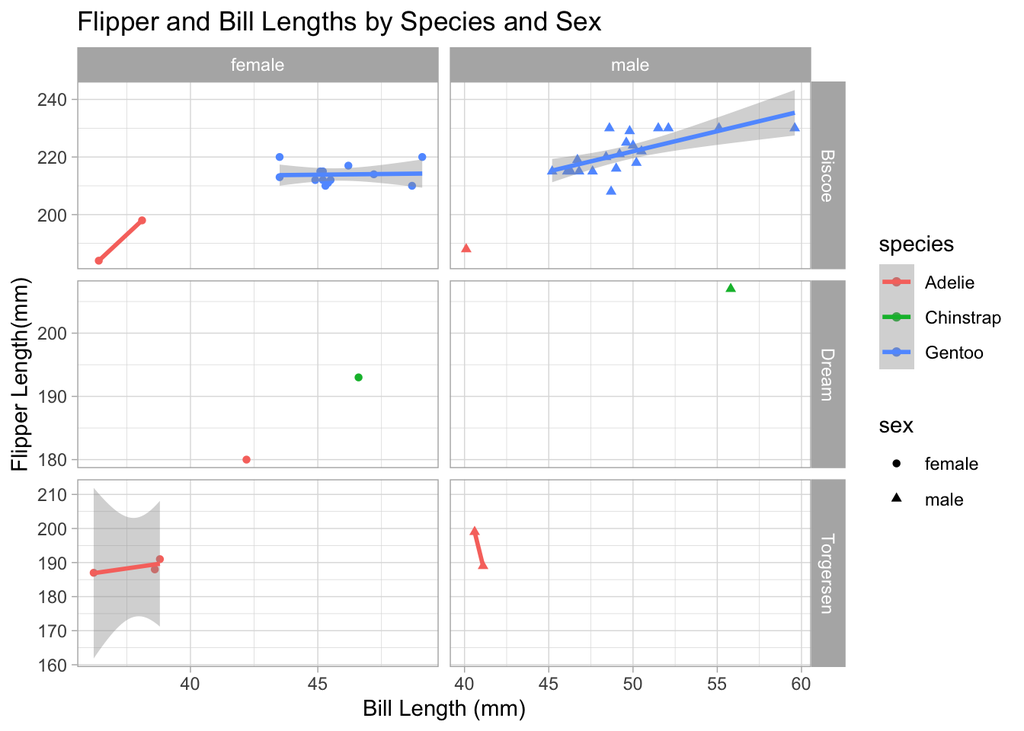

```r
penguins %>%
  filter(!is.na(sex)) %>%
  ggplot() +
  geom_point(mapping = aes(x = bill_length_mm,
                           y = flipper_length_mm,
                           color = species,
                           shape = sex)) +
  geom_smooth(mapping = aes(x = bill_length_mm,
                            y = flipper_length_mm,
                            color = species),
              method = "lm") +
  facet_grid(island ~ sex, scales = "free") +
  labs(title = "Flipper and Bill Lengths by Species and Sex",
       x = "Bill Length (mm)",
       y = "Flipper Length(mm)") +
  theme_light()
```

+ The plot shown above is representing several different types of data. It consists of flipper length, species, sex, and island. The data is basically set up with basic plots showing flipper length within one sex among the different species and then are compared to each other based off of sex and the island that they are one.

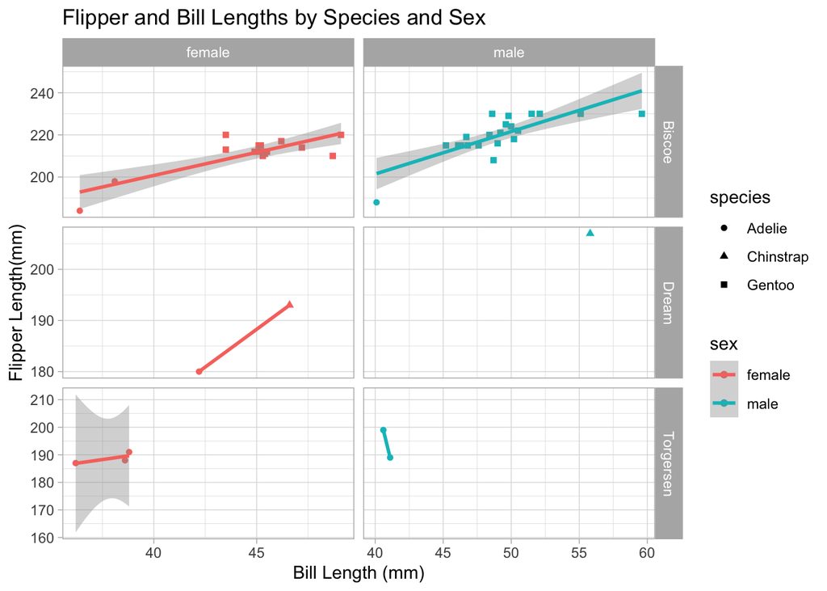

```r
penguins %>%
  filter(!is.na(species)) %>%
  ggplot() +
  geom_point(mapping = aes(x = bill_length_mm,
                           y = flipper_length_mm,
                           color = sex,
                           shape = species)) +
  geom_smooth(mapping = aes(x = bill_length_mm,
                            y = flipper_length_mm,
                            color = sex),
              method = "lm") +
  facet_grid(island ~ sex, scales = "free") +
  labs(title = "Flipper and Bill Lengths by Species and Sex",
       x = "Bill Length (mm)",
       y = "Flipper Length(mm)") +
  theme_light()
```

- All I did in this was interchange the sex and species to see how it would be displayed in the graph. Honestly, I hate this and I think that the other way was much easier to understand. In areas where there are a lot of penguins, for example the male biscoe area, the shapes are kind of clumped together and you can’t really pinpoint what’s going on.

# Final Question

This question we did in class but the average bill length did exceed 45 mm.